# Quick Start Guide to sapfluxr

Grant Joyce

2025-10-21

# Introduction

**sapfluxr** processes and analyses sap flow data from ICT SFM1x heat pulse velocity (HPV) sensors. This guide walks you through the complete workflow from raw data to visualised results.

## Installation

```r
# Install from GitHub
devtools::install_github("neez777/sapfluxr")
```

```r
library(sapfluxr)
library(ggplot2)  # For plotting
```

# Basic Workflow

## 1. Import Data

sapfluxr automatically detects and imports multiple data formats from ICT sensors:

```r
# Import raw heat pulse data
heat_pulse_data <- read_heat_pulse_data("path/to/your/data.txt")
```

The import function will: - Auto-detect the file format (ICT current, legacy, or CSV) - Parse temperature measurements from all four thermistors (do, di, uo, ui) - Extract diagnostic information (battery voltage, temperature, etc.) - Validate data quality (if `validate_data = TRUE`)

### Inspect Imported Data

```r
# Summary of imported data
str(heat_pulse_data, max.level = 2)
```

```
#> List of 3
#>  $ measurements:'data.frame':    1500 obs. of  6 variables:
#>   ..$ pulse_id: int [1:1500] 1 1 1 1 1 1 1 1 1 1 ...
#>   ..$ datetime: POSIXct[1:1500], format: "2024-03-15 08:00:00" "2024-03-15 08:00:01" ...
#>   ..$ do      : num [1:1500] 18.6 18.6 18.6 18.7 18.6 ...
#>   ..$ di      : num [1:1500] 18.3 18.4 18.3 18.4 18.4 ...
#>   ..$ uo      : num [1:1500] 18.6 18.6 18.6 18.7 18.6 ...
#>   ..$ ui      : num [1:1500] 18.4 18.4 18.4 18.4 18.4 ...
#>  $ diagnostics :'data.frame':    10 obs. of  7 variables:
#>   ..$ pulse_id        : int [1:10] 1 2 3 4 5 6 7 8 9 10
#>   ..$ datetime        : POSIXct[1:10], format: "2024-03-15 08:00:00" "2024-03-15 08:30:00" ...
#>   ..$ batt_volt       : num [1:10] 3.94 4.07 4.01 4.05 3.95 ...
#>   ..$ batt_current    : num [1:10] 16.7 14.2 13.8 15 16.2 ...
#>   ..$ batt_temp       : num [1:10] 27.8 27 24 27.7 21.8 ...
#>   ..$ external_volt   : num [1:10] 19.7 20.1 20.4 22.7 20.9 ...
#>   ..$ external_current: num [1:10] 13.6 19.4 17.3 18.5 17.7 ...
#>  $ metadata    :List of 11
#>   ..$ file_path      : chr "example_data.txt"
#>   ..$ file_name      : chr "example_data.txt"
#>   ..$ format         : chr "ict_current"
#>   ..$ import_time    : POSIXct[1:1], format: "2025-10-21 20:08:55"
#>   ..$ file_size      : num 125000
#>   ..$ file_size_mb   : num 0.12
#>   ..$ n_pulses       : num 10
#>   ..$ n_measurements : int 1500
#>   ..$ chunk_size     : num 1e+05
#>   ..$ r_version      : chr "4.5.1"
#>   ..$ package_version: chr "0.2.0"
#>  - attr(*, "class")= chr [1:2] "heat_pulse_data" "list"
```

```r
# View first few temperature measurements
head(heat_pulse_data$measurements)
```

```
#>   pulse_id            datetime       do       di       uo       ui
#> 1        1 2024-03-15 08:00:00 18.64788 18.33344 18.63690 18.35142
#> 2        1 2024-03-15 08:00:01 18.64870 18.38433 18.63693 18.35882
#> 3        1 2024-03-15 08:00:02 18.62395 18.31709 18.63251 18.37673
#> 4        1 2024-03-15 08:00:03 18.66819 18.37312 18.65049 18.37029
#> 5        1 2024-03-15 08:00:04 18.61334 18.35141 18.62813 18.36532
#> 6        1 2024-03-15 08:00:05 18.64013 18.39068 18.63174 18.35219
```

```r
# View diagnostic information
head(heat_pulse_data$diagnostics)
```

```
#>   pulse_id            datetime batt_volt batt_current batt_temp external_volt
#> 1        1 2024-03-15 08:00:00  3.941455     16.70443  27.84594      19.73124
#> 2        2 2024-03-15 08:30:00  4.070029     14.21129  26.96575      20.13023
#> 3        3 2024-03-15 09:00:00  4.013634     13.75766  23.97146      20.42936
#> 4        4 2024-03-15 09:30:00  4.047578     14.97117  27.66932      22.65284
#> 5        5 2024-03-15 10:00:00  3.946977     16.20848  21.79344      20.85909
#> 6        6 2024-03-15 10:30:00  3.921512     16.69582  25.06269      20.32345
#>   external_current
#> 1         13.60032
#> 2         19.41447
#> 3         17.29443
#> 4         18.49753
#> 5         17.72918
#> 6         17.55470
```

## 2. Calculate Heat Pulse Velocity

Calculate sap velocity using one or more established methods:

```r
# Calculate using multiple methods
vh_results <- calc_heat_pulse_velocity(
  heat_pulse_data,
  methods = c("HRM", "MHR", "HRMXa", "Tmax_Klu"),
  show_progress = FALSE
)
```

```
#>
#> ===================================================================
#>   CALCULATION SUMMARY
#> ===================================================================
#>
#> Total pulses processed: 10
#>
#> Success rates by method:
#> -------------------------------------------------------------------
#> Method          Calculated    Missing  Success %
#> -------------------------------------------------------------------
#> HRM                     20          0     100.0%
#> MHR                     20          0     100.0%
#> HRMXa                   20          0     100.0%
#> Tmax_Klu                 0         20       0.0%
#> -------------------------------------------------------------------
#>
#> Quality flags:
#>   MISSING             : 20
#>   OK                  : 60
#>
#> ===================================================================
#>
#> Note: Probe corrections not applied. For accurate results, consider:
#>   1. Collecting zero-flow calibration data
#>   2. Measuring wood properties from cores
#>   3. Estimating wound diameter
#>   4. Using apply_hpv_corrections() before flux calculations
#> Set options(sapfluxr.suppress_correction_warnings = TRUE) to suppress this message.
```

```r
# View results
head(vh_results)
```

```
#>              datetime pulse_id method sensor_position  Vh_cm_hr
#> 1 2024-03-15 08:00:00        1    HRM           outer 42.449648
#> 2 2024-03-15 08:00:00        1    HRM           inner 31.878185
#> 3 2024-03-15 08:00:00        1    MHR           outer  7.354761
#> 4 2024-03-15 08:00:00        1    MHR           inner  6.185518
#> 5 2024-03-15 08:00:00        1  HRMXa           outer  6.998871
#> 6 2024-03-15 08:00:00        1  HRMXa           inner  6.792039
#>   calc_window_start_sec calc_window_end_sec calc_time_sec peclet_number
#> 1                    60                  99            NA      2.358314
#> 2                    60                  99            NA      1.771010
#> 3                    30                  32            NA            NA
#> 4                    28                  31            NA            NA
#> 5                     8                  46            NA            NA
#> 6                     8                  53            NA            NA
#>   selected_method quality_flag
#> 1            <NA>           OK
#> 2            <NA>           OK
#> 3            <NA>           OK
#> 4            <NA>           OK
#> 5            <NA>           OK
#> 6            <NA>           OK
```

### Available Calculation Methods

| Method | Best For | Reference |
| --- | --- | --- |
| **HRM** | Low flows, reverse flows | Burgess et al. (2001) |
| **MHR** | Moderate flows | Lopez et al. (2021) |
| **HRMXa/b** | Enhanced HRM accuracy | Burgess & Bleby (unpublished) |
| **Tmax_Coh** | High flows | Cohen et al. (1981) |
| **Tmax_Klu** | High flows (adjusted) | Kluitenberg & Ham (2004) |

**Note:** DMA (Dual Method Approach) is applied as post-processing using `apply_sdma_processing()` - see section below.

### Understanding the Output

```r
# Results structure
colnames(vh_results)
```

```
#>  [1] "datetime"              "pulse_id"              "method"
#>  [4] "sensor_position"       "Vh_cm_hr"              "calc_window_start_sec"
#>  [7] "calc_window_end_sec"   "calc_time_sec"         "peclet_number"
#> [10] "selected_method"       "quality_flag"
```

```r
# Quality flags
table(vh_results$quality_flag)
```

```
#>
#> MISSING      OK
#>      20      60
```

```r
# Summary by method
aggregate(Vh_cm_hr ~ method, data = vh_results, FUN = function(x) {
  c(mean = mean(x, na.rm = TRUE),
    sd = sd(x, na.rm = TRUE),
    n = sum(!is.na(x)))
})
```

```
#>   method Vh_cm_hr.mean Vh_cm_hr.sd Vh_cm_hr.n
#> 1    HRM    17.4324130  10.2355706 20.0000000
#> 2  HRMXa     7.0647735   0.4657276 20.0000000
#> 3    MHR     6.9946109   0.3618595 20.0000000
```

## 3. Visualise Results

### Time Series Plot

```
#>
#> ===================================================================
#> PLOT SUMMARY
#> ===================================================================
#> Date range: 2024-03-15 08:00 to 2024-03-15 12:30
#> Duration: 0.2 days
#> Methods: HRM, MHR, HRMXa
#> Sensor position: outer
#> Data points: 30
#>
#> Data points per method:
#>   HRM            : 10
#>   HRMXa          : 10
#>   MHR            : 10
#> ===================================================================
```

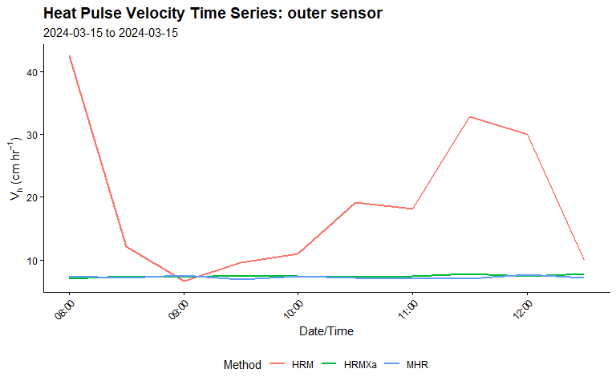

```r
# Plot velocity time series
plot_vh_timeseries(
  vh_results,
  methods = c("HRM", "MHR", "HRMXa"),
  sensor_position = "outer"
)
```

### Heat Pulse Trace Plot

Visualise individual heat pulse responses and see exactly where each method calculated its result:

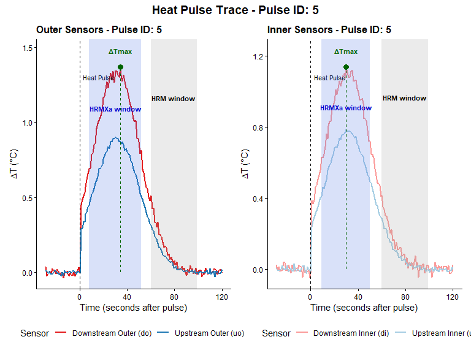

```r
# Plot trace for a single pulse
plot_heat_pulse_trace(
  heat_pulse_data,
  vh_results,
  pulse_id = 5,
  show_methods = c("HRM", "HRMXa", "Tmax_Klu")
)
```

The shaded regions and markers show which time points each method used for its calculation: - **HRM**: Grey shaded window showing averaging period - **HRMXa**: Blue shaded window showing averaging period - **HRMXb**: Green shaded window showing averaging period - **MHR**: Orange shaded window showing time span from upstream to downstream peak, with orange points and lines marking both upstream and downstream peaks - **Tmax methods**: Dark green vertical line and point marking time to maximum temperature

This is invaluable for: - Understanding why methods give different results - Diagnosing problematic pulses - Validating calculation windows - Visualizing the temporal dynamics of heat pulse transport

### Method Comparison

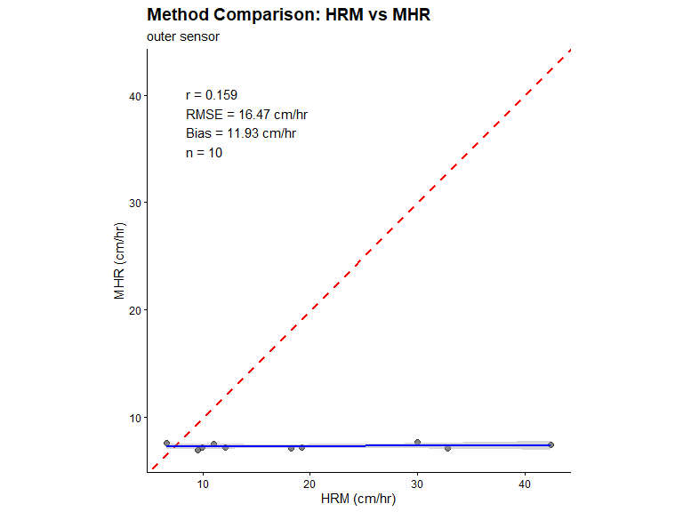

```r
# Compare two methods across all pulses
plot_method_comparison(
  vh_results,
  method1 = "HRM",
  method2 = "MHR",
  sensor_position = "outer"
)
```

## Selectable Dual Method Approach (sDMA)

The **Selectable DMA** (sDMA) is an advanced post-processing method that allows you to choose which high-flow method to pair with HRM. This provides an automatic method selection based on flow conditions.

### How sDMA Works

sDMA automatically switches between two methods based on the **Peclet number (Pe)**:

- **Pe < 1.0**: Uses HRM (optimal for low flows)
- **Pe ≥ 1.0**: Uses your chosen secondary method (optimal for high flows)

The Peclet number is calculated from the HRM velocity: `Pe = (Vh_HRM × probe_spacing) / (diffusivity × 3600)`

### Why Post-Processing?

**New Workflow (Efficient):**

```r
# Step 1: Calculate base methods (each calculated once)
vh <- calc_heat_pulse_velocity(
  heat_pulse_data,
  methods = c("HRM", "MHR", "Tmax_Klu")
)

# Step 2: Apply sDMA switching as post-processing
vh_sdma <- apply_sdma_processing(vh, secondary_method = "MHR")

# Now have: HRM, MHR, Tmax_Klu, sDMA:MHR (all in one tibble)
```

**Benefits:** - Each method calculated exactly once (no redundancy) - Can apply sDMA after corrections: `apply_hpv_corrections() %>% apply_sdma_processing()` - Can test multiple secondary methods without recalculating HRM - More explicit about what’s happening

### Using sDMA

```r
# Step 1: Calculate base methods including HRM (required for Peclet numbers)
vh <- calc_heat_pulse_velocity(
  heat_pulse_data,
  methods = c("HRM", "MHR"),
  show_progress = FALSE
)
```

```
#>
#> ===================================================================
#>   CALCULATION SUMMARY
#> ===================================================================
#>
#> Total pulses processed: 10
#>
#> Success rates by method:
#> -------------------------------------------------------------------
#> Method          Calculated    Missing  Success %
#> -------------------------------------------------------------------
#> HRM                     20          0     100.0%
#> MHR                     20          0     100.0%
#> -------------------------------------------------------------------
#>
#> Quality flags:
#>   OK                  : 40
#>
#> ===================================================================
#>
#> Note: Probe corrections not applied. For accurate results, consider:
#>   1. Collecting zero-flow calibration data
#>   2. Measuring wood properties from cores
#>   3. Estimating wound diameter
#>   4. Using apply_hpv_corrections() before flux calculations
#> Set options(sapfluxr.suppress_correction_warnings = TRUE) to suppress this message.
```

```r
# Step 2: Apply sDMA processing with MHR as secondary method
vh_sdma <- apply_sdma_processing(
  vh,
  secondary_method = "MHR",
  show_progress = FALSE
)

# View sDMA-specific columns
head(vh_sdma[vh_sdma$method == "sDMA:MHR",
             c("datetime", "method", "Vh_cm_hr",
               "peclet_number", "selected_method")])
```

```
#>               datetime   method  Vh_cm_hr peclet_number selected_method
#> 41 2024-03-15 08:00:00 sDMA:MHR  7.354761     2.3583138             MHR
#> 42 2024-03-15 08:00:00 sDMA:MHR  6.185518     1.7710103             MHR
#> 43 2024-03-15 08:30:00 sDMA:MHR 12.082997     0.6712776             HRM
#> 44 2024-03-15 08:30:00 sDMA:MHR  7.098753     1.1159224             MHR
#> 45 2024-03-15 09:00:00 sDMA:MHR  6.620169     0.3677872             HRM
#> 46 2024-03-15 09:00:00 sDMA:MHR  7.525033     0.4180574             HRM
```

The `selected_method` column shows which method was actually used for each measurement (HRM or MHR).

### Compare Multiple sDMA Variants

You can test multiple secondary methods to find which works best for your data:

```r
# Calculate base methods once
vh <- calc_heat_pulse_velocity(
  heat_pulse_data,
  methods = c("HRM", "MHR", "Tmax_Klu"),
  show_progress = FALSE
)
```

```
#>
#> ===================================================================
#>   CALCULATION SUMMARY
#> ===================================================================
#>
#> Total pulses processed: 10
#>
#> Success rates by method:
#> -------------------------------------------------------------------
#> Method          Calculated    Missing  Success %
#> -------------------------------------------------------------------
#> HRM                     20          0     100.0%
#> MHR                     20          0     100.0%
#> Tmax_Klu                 0         20       0.0%
#> -------------------------------------------------------------------
#>
#> Quality flags:
#>   MISSING             : 20
#>   OK                  : 40
#>
#> ===================================================================
#>
#> Note: Probe corrections not applied. For accurate results, consider:
#>   1. Collecting zero-flow calibration data
#>   2. Measuring wood properties from cores
#>   3. Estimating wound diameter
#>   4. Using apply_hpv_corrections() before flux calculations
#> Set options(sapfluxr.suppress_correction_warnings = TRUE) to suppress this message.
```

```r
# Apply sDMA with multiple secondary methods at once
vh_multi_sdma <- apply_sdma_processing(
  vh,
  secondary_method = c("MHR", "Tmax_Klu"),
  show_progress = FALSE
)

# Now have: HRM, MHR, Tmax_Klu, sDMA:MHR, sDMA:Tmax_Klu
unique(vh_multi_sdma$method)
```

```
#> [1] "HRM"           "MHR"           "Tmax_Klu"      "sDMA:MHR"
#> [5] "sDMA:Tmax_Klu"
```

```r
# Summary by method
aggregate(Vh_cm_hr ~ method, data = vh_multi_sdma, FUN = mean, na.rm = TRUE)
```

```
#>          method  Vh_cm_hr
#> 1           HRM 17.432413
#> 2           MHR  6.994611
#> 3      sDMA:MHR  8.525392
#> 4 sDMA:Tmax_Klu  9.781387
```

### Visualising sDMA Results

The dedicated sDMA plotting function shows:

- Velocity points colored by which method was selected (HRM vs secondary)
- Peclet number on a secondary y-axis (grey line)
- The Pe = 1.0 switching threshold (dashed horizontal line)
- Legend includes both selected methods and the Peclet number line

```r
# Plot sDMA time series with Peclet number
plot_sdma_timeseries(
  vh_sdma,
  sdma_method = "sDMA:MHR",
  sensor_position = "outer"
)

# Plot without Peclet number
plot_sdma_timeseries(
  vh_sdma,
  sdma_method = "sDMA:MHR",
  sensor_position = "outer",
  show_peclet = FALSE
)
```

The plot legend shows which method was used for each data point (and the Peclet number when `show_peclet = TRUE`), and the summary statistics tell you what percentage of measurements used HRM vs the secondary method.

### When to Use sDMA

Use sDMA when:

- **You have variable flow conditions**: Data spans both low and high flow regimes
- **You want method transparency**: sDMA shows exactly which method was used via `selected_method` column
- **Tmax methods fail frequently**: Try `sDMA:MHR` as an alternative to standard DMA (which uses Tmax_Klu)
- **You want to analyse flow regimes**: The `peclet_number` column reveals flow conditions over time

### Advanced: sDMA After Corrections

The post-processing approach allows you to apply sDMA after making probe corrections:

```r
# Calculate base methods
vh <- calc_heat_pulse_velocity(heat_pulse_data, methods = c("HRM", "MHR"))

# Apply corrections (wound diameter, zero-flow, etc.)
vh_corrected <- apply_hpv_corrections(vh, corrections)

# Then apply sDMA to corrected results
vh_sdma <- apply_sdma_processing(vh_corrected, secondary_method = "MHR")
```